# VLMC cells from C-B, 2018

RA ([numpde](https://github.com/numpde/))

2021-04-30

## Preliminaries

### Setup

```r
suppressPackageStartupMessages({
  # install.packages("kableExtra")
  requireNamespace("kableExtra")

  # install.packages("crunch")
  requireNamespace("crunch")

  # https://rstudio.github.io/DT/
  # install.packages("DT")
  requireNamespace("DT")

  # may need to say "don't restart session"
  # install.packages("RCurl")
  requireNamespace("RCurl")

  # install.packages("dplyr")
  library(dplyr)
  # install.packages("ggplot2")
  library(ggplot2)

  #
  requireNamespace("magrittr")
  `%<>%` <- magrittr::`%<>%`
  `%>%` <- magrittr::`%>%`

  #
  requireNamespace("tidyr")

  # BiocManager::install("org.Mm.eg.db")
  requireNamespace("org.Mm.eg.db")

  # https://www.bioconductor.org/packages/release/bioc/vignettes/goseq/inst/doc/goseq.pdf
  # BiocManager::install("goseq")
  requireNamespace("goseq")

  # https://vroom.r-lib.org/articles/vroom.html
  # install.packages("vroom")
  requireNamespace("vroom")

  # BiocManager::install("DESeq2")
  requireNamespace("DESeq2")

  # BiocManager::install("scater")
  requireNamespace("scater")

  # BiocManager::install("scran")
  requireNamespace("scran")

  # BiocManager::install("igraph")
  requireNamespace("igraph")

  # install.packages("pheatmap")
  requireNamespace("pheatmap")
  # install.packages("stringr")
  requireNamespace("stringr")
  # install.packages("reshape2")
  requireNamespace("reshape2")
  # install.packages("pathlibr")
  requireNamespace("pathlibr")
  # install.packages("pbapply")
  requireNamespace("pbapply")

  # install.packages("Rtsne")
  requireNamespace("Rtsne")
  # install.packages("uwot")
  requireNamespace("uwot")

  # avoid importing `exprs` that leads to clashes
  requireNamespace("rlang")

  # install.packages("Seurat")
  requireNamespace("Seurat")

  # BiocManager::install("TrajectoryUtils") # Didn't work
  # devtools::install_github("LTLA/TrajectoryUtils@e943606")
  # BiocManager::install("kstreet13/slingshot@25fc566")
  requireNamespace("slingshot")

  # BiocManager::install("tradeSeq")
  requireNamespace("tradeSeq")

  # Monocle3
  # https://cole-trapnell-lab.github.io/monocle3/docs/installation/
  # BiocManager::install(c("BiocGenerics", "DelayedArray", "DelayedMatrixStats", "limma", "S4Vectors", "SingleCellExperiment", "SummarizedExperiment", "batchelor", "Matrix.utils"))
  # install.packages("devtools")
  # devtools::install_github("cole-trapnell-lab/leidenbase@8c52ebc")
  # apt install libudunits2-dev libgdal-dev libgeos-dev libproj-dev
  # devtools::install_github("cole-trapnell-lab/monocle3@4c01d89")
  # requireNamespace("monocle3") #
})
```

[output not shown]

[output not shown]

[output not shown]

[output not shown]

[output not shown]

[output not shown]

[output not shown]

[output not shown]

[output not shown]

[output not shown]

[output not shown]

[output not shown]

[output not shown]

[output not shown]

[output not shown]

[output not shown]

[output not shown]

[output not shown]

[output not shown]

[output not shown]

[output not shown]

[output not shown]

[output not shown]

[output not shown]

[output not shown]

[output not shown]

[output not shown]

[output not shown]

[output not shown]

[output not shown]

[output not shown]

[output not shown]

[output not shown]

[output not shown]

[output not shown]

[output not shown]

[output not shown]

[output not shown]

[output not shown]

[output not shown]

[output not shown]

[output not shown]

[output not shown]

[output not shown]

[output not shown]

[output not shown]

[output not shown]

[output not shown]

[output not shown]

[output not shown]

[output not shown]

[output not shown]

[output not shown]

[output not shown]

[output not shown]

[output not shown]

[output not shown]

[output not shown]

[output not shown]

[output not shown]

[output not shown]

[output not shown]

[output not shown]

[output not shown]

[output not shown]

[output not shown]

[output not shown]

[output not shown]

[output not shown]

[output not shown]

[output not shown]

[output not shown]

[output not shown]

[output not shown]

[output not shown]

[output not shown]

[output not shown]

[output not shown]

[output not shown]

[output not shown]

[output not shown]

[output not shown]

[output not shown]

[output not shown]

[output not shown]

[output not shown]

[output not shown]

[output not shown]

[output not shown]

[output not shown]

[output not shown]

[output not shown]

[output not shown]

[output not shown]

[output not shown]

[output not shown]

[output not shown]

[output not shown]

[output not shown]

[output not shown]

[output not shown]

[output not shown]

[output not shown]

[output not shown]

### PRG

```r
set.seed(43)
```

### Paths

```r
BASEPATH <- pathlibr::Path$new(".")
stopifnot("main.Rmd" %in% names(BASEPATH$dir))
```

```r
path_to <- (function(.) Sys.glob(BASEPATH$join("../..")$join(.)$show))
```

```r
out_file <- (function(.) BASEPATH$join("output")$join(.)$show)
dir.create(out_file(""), showWarnings = FALSE)
```

### Plotting

```r
ggplot2::theme_set(theme_light(base_size = 15))
```

```r
kable <- function(.) {
  kableExtra::kbl(., align = "c") %>%
    kableExtra::kable_paper("hover", full_width = F)
}
```

```r
options(DT.options = list(
  pageLength = 16,
  language = list(search = "Filter:")
))
```

```r
as.link <-
  function(x) {
    dplyr::case_when(
      # If x is like GO:003453
      startsWith(x, "GO:") ~ paste0(
        "<a target='_blank'",
        "href='", "http://amigo.geneontology.org/amigo/term/", x, "'",
        ">", x, "</a>"
      ),
      # Otherwise try this
      TRUE ~ paste0(
        "<a target='_blank'",
        "href='", "http://www.informatics.jax.org/marker/summary?nomen=", x, "'",
        ">", x, "</a>"
      )
    )
  }
```

```r
show_de_table <- function(.) {
  (.) %>%
    select(base = baseMean, l2fc = log2FoldChange, p = pvalue, padj) %>%
    ind2col("symbol") %>%
    mutate(symbol = as.link(symbol)) %>%
    DT::datatable(escape = FALSE) %>%
    DT::formatSignif(c("base", "l2fc", "p", "padj"), digits = 3)
}
```

```r
show_go_table <- function(.) {
  (.) %>%
    dplyr::select("category", "overrep.p", "#DE", "#cat", "term", "GO") %>%
    DT::datatable(escape = FALSE) %>%
    DT::formatSignif("overrep.p", digits = 3)
}
```

### Dataframes

```r
# Use first column as index
by_col1 <- (function(.) tibble::column_to_rownames(., colnames(.)[1]))
# Use index as new column `name`
ind2col <- (function(., name) tibble::rownames_to_column(., var = name))
```

```r
arrange.like <- (function(X, T) X[rownames(T), , drop = FALSE])
rows.of <- (function(rows, X) X[rows, , drop = FALSE])
```

```r
Sys.setenv("VROOM_CONNECTION_SIZE" = 131072 * 4)
from_csv <- function(.) {
  vroom::vroom(., del = "\t", progress = FALSE) %>%
    by_col1() %>%
    suppressMessages()
}
```

A call to `to_csv` should be preceded by `ind2col("name for index")` to write the row names.

```r
to_csv <- function(., f) {
  vroom::vroom_write(., out_file(f), delim = "\t")
}
```

The following function constructs a `SingleCellExperiment`, while checking consistency of sample names.

```r
make_sce <- function(counts, coldata) {
  # Check that samples in counts = genes x samples
  # are ordered as in coldata = samples x metafields
  stopifnot(assertthat::are_equal(colnames(counts), rownames(coldata)))
  SingleCellExperiment::SingleCellExperiment(
    assays = list(counts = counts), colData = coldata
  )
}
```

### Misc

If A and B are SingleCellExperiment-like, then `cosine` computes the cosine similarity of of samples of A against samples of B.

```r
cosine <- function(A, B) {
  A <- A@assays@data$counts
  B <- B@assays@data$counts
  ii <- intersect(rownames(A), rownames(B))
  A <- t(as.matrix(A[ii, , drop = FALSE]))
  B <- t(as.matrix(B[ii, , drop = FALSE]))
  A <- A / sqrt(rowSums(A * A))
  B <- B / sqrt(rowSums(B * B))
  A %*% t(B)
}
```

## Datasets

### Castelo-Branco, 2018

#### About

Raw data from GSE113973 (last update: Nov 13, 2019), metadata from [UCSC cell browser](https://cells.ucsc.edu/?ds=oligo-lineage-ms).

Other links: [web app](https://castelobranco.shinyapps.io/EAE2017/), [paper](https://www.nature.com/articles/s41591-018-0236-y).

#### Load

```r
sce_cb <-
  make_sce(
    counts = (
      path_to("*/CasteloBranco-2018/*/expr.csv.gz") %>%
        from_csv()
    ),
    coldata = (
      path_to("*/CasteloBranco-2018/*/meta.csv.gz") %>%
        from_csv()
    )
  ) %>%
  # Only keep those cells
  `[`(, (.)$celltype %in% c("VLMC1", "VLMC2", "VLMC3", "VLMC4")) %>%
  # Order by cell type
  `[`(, order((.)$celltype))

# conversion to matrix takes long, hence do it here
sce_cb@assays@data$counts %<>% as.matrix()
```

#### Diagnostics

Attach diagnostics by scater.

```r
sce_cb %<>% (function(sce) {
  scater::addPerCellQC(
    x = sce,
    subsets = list(Mito = grep("mt-", rownames(sce)))
  ) %>%
    scater::logNormCounts() %>%
    scater::runPCA(name = "PCA", ncomponents = 20) %>%
    scater::runTSNE(perplexity = 10, dimred = "PCA") %>%
    scater::runUMAP()
})
```

Projections:

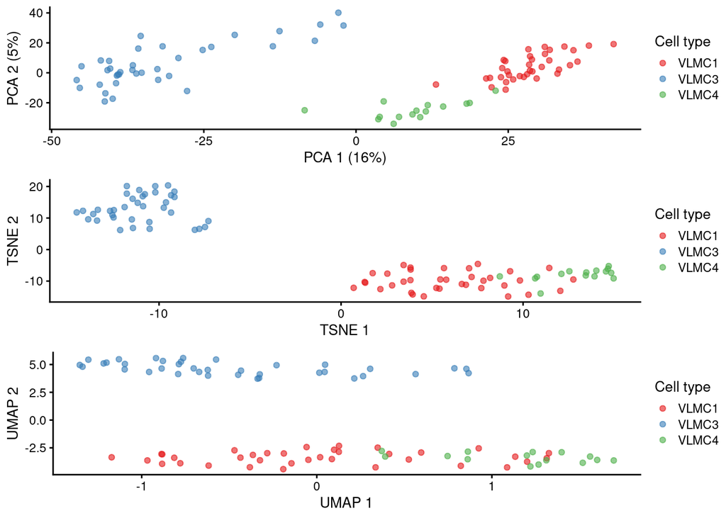

```r
sce_cb %>%
  {
    function(which_dimred) {
      scater::plotReducedDim(
        dimred = which_dimred,
        object = (.),
        colour_by = "celltype"
      ) +
        scale_color_brewer(palette = "Set1", name = "Cell type")
    }
  } %>%
  {
    gridExtra::grid.arrange((.)("PCA"), (.)("TSNE"), (.)("UMAP"), nrow = 3)
  }
```

### Betsholtz, 2018

#### About

GSE98816: single cell RNA-seq of mouse brain vascular transcriptomes.

#### Load

```r
sce_bth_mb <-
  make_sce(
    counts = (
      path_to("*/Betsholtz-2018/*/expr.csv.gz") %>%
        from_csv() %>%
        t()
    ),
    coldata = (
      path_to("*/Betsholtz-2018/*/meta.csv.gz") %>%
        from_csv()
    )
  ) %>%
  # Only keep FB
  `[`(, (.)$celltype %in% c("FB1", "FB2")) %>%
  # Order by cell type
  `[`(, order((.)$celltype))

# conversion to matrix takes long, hence do it here
sce_bth_mb@assays@data$counts %<>% as.matrix()
```

#### Diagnostics

Attach diagnostics by scater.

```r
sce_bth_mb %<>% (function(sce) {
  scater::addPerCellQC(
    x = sce,
    subsets = list(Mito = grep("mt-", rownames(sce)))
  ) %>%
    scater::logNormCounts() %>%
    scater::runPCA(name = "PCA", ncomponents = 20) %>%
    scater::runTSNE(perplexity = 10, dimred = "PCA") %>%
    scater::runUMAP()
})
```

Projections:

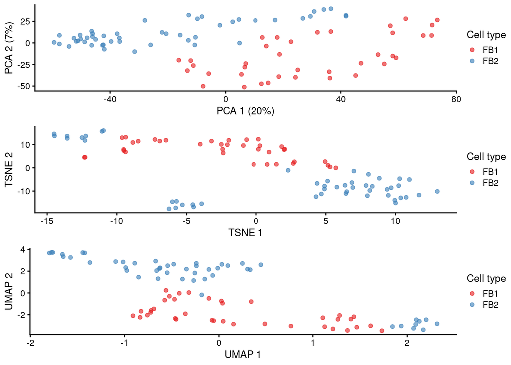

```r
sce_bth_mb %>%
  {
    function(which_dimred) {
      scater::plotReducedDim(
        dimred = which_dimred,
        object = (.),
        colour_by = "celltype"
      ) +
        scale_color_brewer(palette = "Set1", name = "Cell type")
    }
  } %>%
  {
    gridExtra::grid.arrange((.)("PCA"), (.)("TSNE"), (.)("UMAP"), nrow = 3)
  }
```

### AB – Mouse ctx & hip (10x)

#### About

“Mouse Whole Cortex and Hippocampus 10x” dataset from Allen Brain, 2020: [[explore](https://celltypes.brain-map.org/rnaseq/mouse_ctx-hip_10x)], [[download](https://portal.brain-map.org/atlases-and-data/rnaseq/mouse-whole-cortex-and-hippocampus-10x)], [[protocols](https://portal.brain-map.org/atlases-and-data/rnaseq/protocols-mouse-cortex-and-hippocampus)].

#### Diagnostics

Attach diagnostics by scater.

```r
sce_abm_ch %<>% (function(sce) {
  scater::addPerCellQC(
    x = sce,
    subsets = list(Mito = grep("mt-", rownames(sce)))
  ) %>%
    scater::logNormCounts() %>%
    scater::runPCA(name = "PCA", ncomponents = 20) %>%
    scater::runTSNE(perplexity = 10, dimred = "PCA") %>%
    scater::runUMAP()
})
```

Projections:

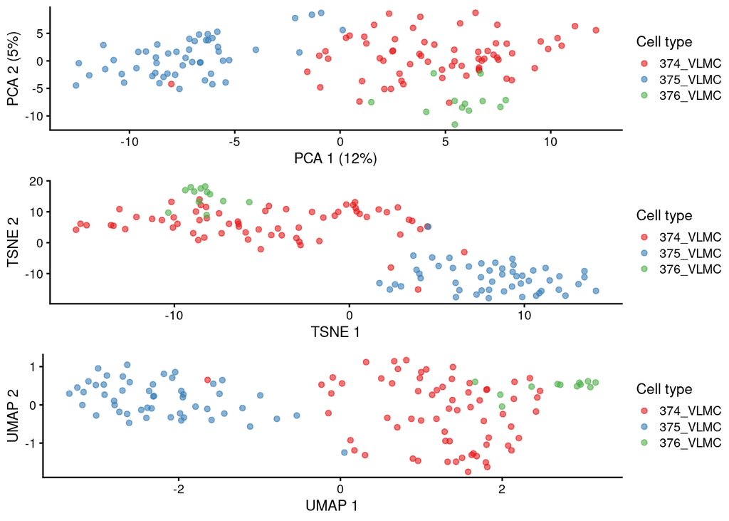

```r
sce_abm_ch %>%
  {
    function(which_dimred) {
      scater::plotReducedDim(
        dimred = which_dimred,
        object = (.),
        colour_by = "cell_type_alias_label"
      ) +
        scale_color_brewer(palette = "Set1", name = "Cell type")
    }
  } %>%
  {
    gridExtra::grid.arrange((.)("PCA"), (.)("TSNE"), (.)("UMAP"), nrow = 3)
  }
```

## Analysis of “Castelo-Branco, 2018”

### Overview

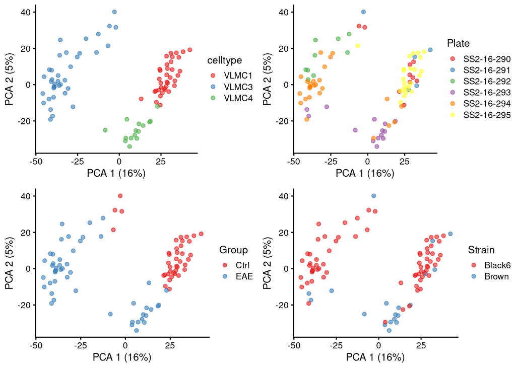

```r
sce_cb %>%
  {
    function(group) {
      scater::plotReducedDim(
        dimred = "PCA",
        object = (.),
        colour_by = group
      ) +
        scale_color_brewer(palette = "Set1", name = group)
    }
  } %>%
  {
    gridExtra::grid.arrange(
      (.)("celltype"), (.)("Plate"),
      (.)("Group"), (.)("Strain"),
      nrow = 2
    )
  }
```

### VLMC3

We first look at what differentiates the VLMC3 cluster.

#### DE genes

```r
sce_cb$celltype %<>%
  as.factor() %>%
  relevel(ref = "VLMC3")

de_results.vlmc3 <-
  sce_cb %>%
  {
    (.) %>%
      DESeq2::DESeqDataSet(design = ~celltype) %>%
      DESeq2::estimateSizeFactors() %>%
      DESeq2::DESeq(quiet = TRUE, fitType = "local") %>%
      DESeq2::results()
  } %>%
  as.data.frame() %>%
  slice_min(pvalue, n = 777)
```

Log2 fold-change is relative to VLMC3. Hence, *negative l2fc* means *up in VLMC3*.

```r
de_results.vlmc3 %>%
  show_de_table()
```

|  | symbol | base | l2fc | p | padj |
| --- | --- | --- | --- | --- | --- |
| 1 | Mamdc2 | 43.2308765150471 | 25.875518601468 | 1.00456000133583e-97 | 8.89738793183143e-94 |
| 2 | F11r | 28.0614563684215 | 25.7966624338349 | 1.43914455432625e-67 | 6.37325165883381e-64 |
| 3 | Vit | 15.9179397540114 | 24.6327016899299 | 1.05944779729449e-52 | 3.1278430468791e-49 |
| 4 | Myoc | 104.050348541829 | 25.9201196456166 | 6.09670559584662e-47 | 1.34996303656034e-43 |
| 5 | Ebf2 | 70.7997952293337 | 10.192646804824 | 3.48448349822839e-42 | 6.17241406876177e-39 |
| 6 | Ptgfr | 18.989419067518 | -23.1791421211786 | 6.01941991936444e-39 | 8.88566703763514e-36 |
| 7 | Moxd1 | 145.49051553252 | -10.8977978333874 | 1.47158218681665e-37 | 1.86197191837644e-34 |
| 8 | Col12a1 | 34.1102112891056 | -24.6987838022311 | 2.74297581426018e-35 | 3.0368170983628e-32 |
| 9 | Col22a1 | 10.4564008404701 | -23.9849642086442 | 5.5472484689997e-35 | 5.45910885443671e-32 |
| 10 | Ctxn3 | 30.9207854504448 | 25.1173700298943 | 7.19283212420937e-35 | 6.37069141241224e-32 |

[output cut: 767 more lines]

#### Heatmap

```
## [1] "Min abs log2 fold-change: 2.02"
```

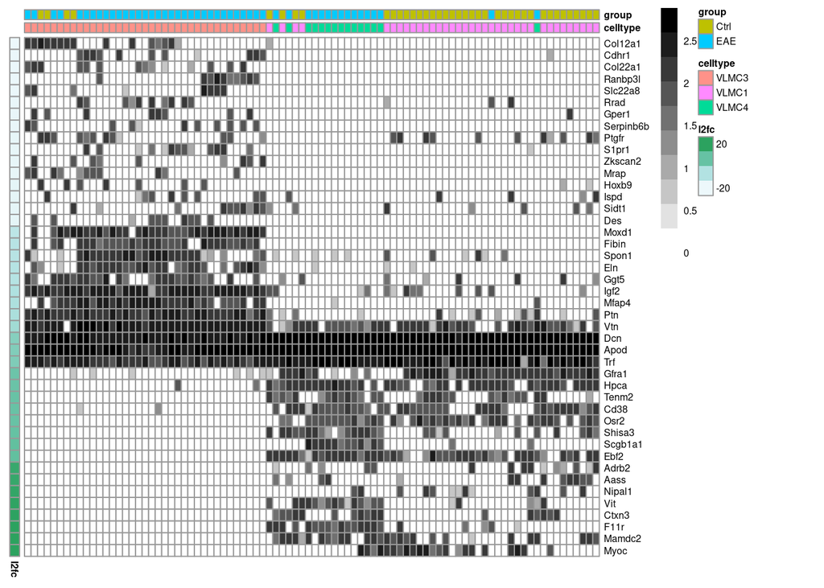

```r
sce_cb %>%
  list(
    sce = .,
    top = de_results.vlmc3 %>%
      slice_min(pvalue, n = 44) %>%
      arrange(log2FoldChange)
  ) %>%
  with({
    print(paste("Min abs log2 fold-change:", round(min(abs(top$log2FoldChange)), 2)))

    sce[rownames(top), ]
  }) %>%
  {
    pheatmap::pheatmap(
      log1p((.)@assays@data$logcount) %>% {
        # (.) / rowSums(.)
      },
      show_colnames = FALSE,
      cluster_cols = TRUE,
      cluster_rows = FALSE,
      treeheight_row = 0,
      treeheight_col = 0,
      fontsize = 6,
      color = grDevices::colorRampPalette(c("white", "black"))(10),
      annotation_col = (
        (.)@colData %>%
          as.data.frame() %>%
          select(celltype, group = Group)
      ),
      annotation_row = (
        de_results.vlmc3 %>%
          select(l2fc = log2FoldChange)
      )
    )
  }
```

#### Compute GO

```r
# Number of genes for GO analysis
n <- 33
```

```r
enriched_go_terms <-
  de_results.vlmc3 %>%
  {
    list(
      up_vlmc3 = (.) %>% filter(log2FoldChange < 0),
      up_other = (.) %>% filter(log2FoldChange > 0)
    )
  } %>%
  lapply(function(.) {
    (.) %>%
      arrange(pvalue) %>%
      rownames()
  }) %>%
  within({
    f <- (function(x) x[1:5] %>% paste(collapse = ", "))
    print(paste("Up in VLMC3:", f(up_vlmc3), "..."))
    print(paste("Up in other:", f(up_other), "..."))
    rm(f)
  }) %>%
  lapply(function(de_results) {
    de_results %>%
      data.frame(symbol = .) %>%
      slice_head(n = n) %>%
      # Get the Entrez IDs of our genes
      merge(
        org.Mm.eg.db::org.Mm.egSYMBOL2EG %>% as.data.frame(),
        by = "symbol"
      ) %>%
      pull(gene_id) %>%
      # Enrichment analysis
      limma::goana(species = "Mm") %>%
      # Limit selection
      filter(P.DE <= 0.05) %>%
      arrange(P.DE) %>%
      # Format for display
      ind2col("category") %>%
      mutate(category = as.link(category)) %>%
      rename(
        # new name = old name
        "overrep.p" = P.DE, "#DE" = DE, "#cat" = N, "GO" = Ont, "term" = Term
      )
  })
```

```
## [1] "Up in VLMC3: Ptgfr, Moxd1, Col12a1, Col22a1, S1pr1 ..."
## [1] "Up in other: Mamdc2, F11r, Vit, Myoc, Ebf2 ..."
```

#### GO up in VLMC3

GO terms associated with 33 “VLMC3” genes.

```r
enriched_go_terms$up_vlmc3 %>% show_go_table()
```

|  | category | overrep.p | #DE | #cat | term | GO |
| --- | --- | --- | --- | --- | --- | --- |
| 1 | GO:0005201 | 1.46400858029904e-11 | 8 | 148 | extracellular matrix structural constituent | MF |
| 2 | GO:0062023 | 4.23171144450724e-11 | 10 | 385 | collagen-containing extracellular matrix | CC |
| 3 | GO:0031012 | 6.91002346583414e-10 | 10 | 513 | extracellular matrix | CC |
| 4 | GO:0071953 | 8.31122268419203e-09 | 3 | 4 | elastic fiber | CC |
| 5 | GO:0005198 | 3.85637026383605e-08 | 9 | 576 | structural molecule activity | MF |
| 6 | GO:0005576 | 7.09843866252334e-08 | 16 | 2750 | extracellular region | CC |
| 7 | GO:0030198 | 2.4326236471449e-06 | 6 | 302 | extracellular matrix organization | BP |
| 8 | GO:0043062 | 2.4794780305492e-06 | 6 | 303 | extracellular structure organization | BP |
| 9 | GO:0005615 | 3.66058190652353e-06 | 12 | 1962 | extracellular space | CC |
| 10 | GO:0007155 | 6.90192106396906e-06 | 10 | 1379 | cell adhesion | BP |

[output cut: 634 more lines]

#### GO up in other

GO terms associated with 33 “other” genes.

```r
enriched_go_terms$up_other %>% show_go_table()
```

|  | category | overrep.p | #DE | #cat | term | GO |
| --- | --- | --- | --- | --- | --- | --- |
| 1 | GO:0062023 | 3.65067046697688e-08 | 8 | 385 | collagen-containing extracellular matrix | CC |
| 2 | GO:0032502 | 2.77919373393942e-07 | 23 | 6449 | developmental process | BP |
| 3 | GO:0031012 | 3.28177352649679e-07 | 8 | 513 | extracellular matrix | CC |
| 4 | GO:0048856 | 4.04874811515246e-07 | 22 | 5977 | anatomical structure development | BP |
| 5 | GO:0007275 | 2.78223270964358e-06 | 20 | 5467 | multicellular organism development | BP |
| 6 | GO:0005576 | 5.557704256877e-06 | 14 | 2750 | extracellular region | CC |
| 7 | GO:0040011 | 2.0929201391811e-05 | 11 | 1863 | locomotion | BP |
| 8 | GO:0005615 | 3.39439181599184e-05 | 11 | 1962 | extracellular space | CC |
| 9 | GO:1902533 | 3.51458105814015e-05 | 8 | 967 | positive regulation of intracellular signal transduction | BP |
| 10 | GO:0007162 | 4.23809661130921e-05 | 5 | 290 | negative regulation of cell adhesion | BP |

[output cut: 939 more lines]

### Ctrl vs EAE (restricted)

Now we look at Ctrl vs EAE cells **only within the “Other” (non-VLMC3) cluster**, which is almost the same as VLMC1 vs VLMC4.

#### DE genes

```r
sce_cb$Group %<>%
  as.factor() %>%
  relevel(ref = "Ctrl")

de_results.group <-
  sce_cb %>%
  `[`(, (.)$celltype != "VLMC3") %>%
  {
    (.) %>%
      DESeq2::DESeqDataSet(design = ~Group) %>%
      DESeq2::estimateSizeFactors() %>%
      DESeq2::DESeq(quiet = TRUE, fitType = "local") %>%
      DESeq2::results()
  } %>%
  as.data.frame() %>%
  slice_min(pvalue, n = 777)
```

Log2 fold-change is relative to the Ctrl group. Hence, *positive l2fc* means *up in EAE*.

```r
de_results.group %>%
  show_de_table()
```

|  | symbol | base | l2fc | p | padj |
| --- | --- | --- | --- | --- | --- |
| 1 | Ptgfr | 14.9662623699679 | -23.453122719847 | 1.96253874098005e-39 | 1.75372461893977e-35 |
| 2 | Tmed8 | 11.0683073670197 | -23.0493851752766 | 6.7428984631466e-14 | 3.0127270333339e-10 |
| 3 | Scgb1a1 | 40.5378510515564 | 7.69300882429774 | 1.32636641792066e-10 | 3.7509228062093e-07 |
| 4 | Cldn11 | 34.4587044817928 | 4.98216902247344 | 1.67901647547417e-10 | 3.7509228062093e-07 |
| 5 | Pamr1 | 15.3656692061707 | 8.20598531730927 | 3.26350804411197e-10 | 5.83254157643692e-07 |
| 6 | Wif1 | 18.4083710189577 | 8.46710267457193 | 5.35987424692987e-10 | 7.98263937842755e-07 |
| 7 | Serpind1 | 16.1051431321159 | 8.1055618607185 | 4.16306999641713e-09 | 5.31445621256906e-06 |
| 8 | Igfbp7 | 329.397977004136 | 2.5110670286353 | 5.5920385840674e-09 | 6.24630709840329e-06 |
| 9 | Apod | 57224.2707064765 | 0.821533328139368 | 1.35166010005796e-08 | 1.34204829490199e-05 |
| 10 | Crip1 | 27.551641879279 | -2.99444701451897 | 2.07590346133494e-08 | 1.85502733304891e-05 |

[output cut: 767 more lines]

#### Heatmap

```
## [1] "Min abs log2 fold-change: 0.82"
```

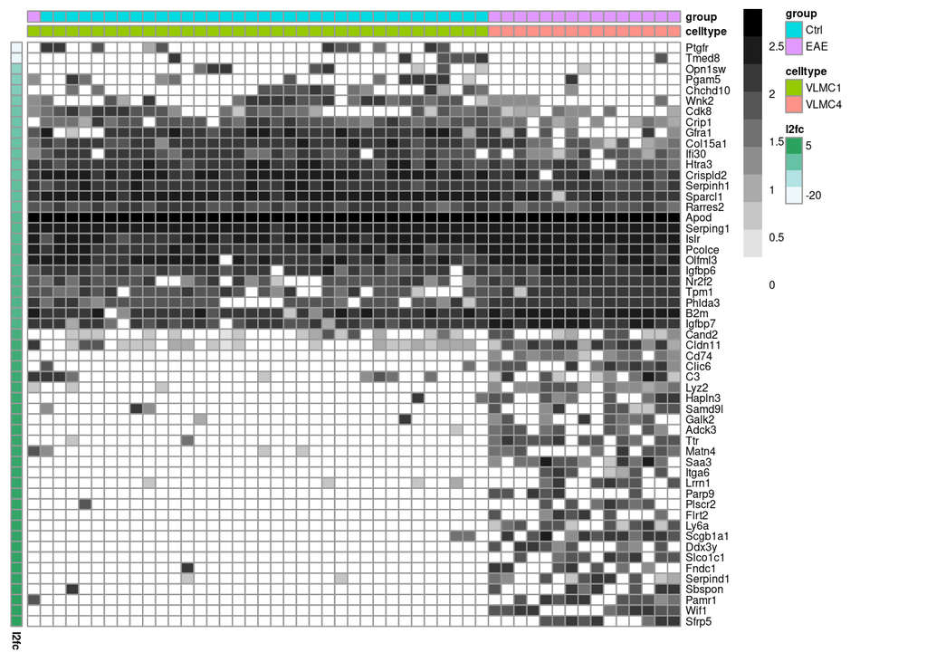

```r
sce_cb %>%
  `[`(, (.)$celltype != "VLMC3") %>%
  list(
    sce = .,
    top = de_results.group %>%
      slice_min(pvalue, n = 55) %>%
      arrange(log2FoldChange)
  ) %>%
  with({
    print(paste("Min abs log2 fold-change:", round(min(abs(top$log2FoldChange)), 2)))
    sce[rownames(top), ]
  }) %>%
  {
    pheatmap::pheatmap(
      log1p((.)@assays@data$logcount) %>% {
        # (.) / rowSums(.)
      },
      show_colnames = FALSE,
      cluster_cols = TRUE,
      cluster_rows = FALSE,
      treeheight_row = 0,
      treeheight_col = 0,
      fontsize = 6,
      color = grDevices::colorRampPalette(c("white", "black"))(10),
      annotation_col = (
        (.)@colData %>%
          as.data.frame() %>%
          select(celltype, group = Group)
      ),
      annotation_row = (
        de_results.group %>%
          select(l2fc = log2FoldChange)
      )
    )
  }
```

#### Compute GO

```r
# Number of genes for GO analysis
n <- 33
```

```r
enriched_go_terms <-
  de_results.group %>%
  {
    list(
      up_ctrl = (.) %>% filter(log2FoldChange < 0),
      up_eae = (.) %>% filter(log2FoldChange > 0)
    )
  } %>%
  lapply(function(.) {
    (.) %>%
      arrange(pvalue) %>%
      rownames()
  }) %>%
  within({
    f <- (function(x) x[1:5] %>% paste(collapse = ", "))
    print(paste("Up in Ctrl:", f(up_ctrl), "..."))
    print(paste("Up in EAE: ", f(up_eae), "..."))
    rm(f)
  }) %>%
  lapply(function(de_results) {
    de_results %>%
      data.frame(symbol = .) %>%
      slice_head(n = n) %>%
      # Get the Entrez IDs of our genes
      merge(
        org.Mm.eg.db::org.Mm.egSYMBOL2EG %>% as.data.frame(),
        by = "symbol"
      ) %>%
      pull(gene_id) %>%
      # Enrichment analysis
      limma::goana(species = "Mm") %>%
      # Limit selection
      filter(P.DE <= 0.05) %>%
      arrange(P.DE) %>%
      # Format for display
      ind2col("category") %>%
      mutate(category = as.link(category)) %>%
      rename(
        # new name = old name
        "overrep.p" = P.DE, "#DE" = DE, "#cat" = N, "GO" = Ont, "term" = Term
      )
  })
```

```
## [1] "Up in Ctrl: Ptgfr, Tmed8, Crip1, Col15a1, Crispld2 ..."
## [1] "Up in EAE:  Scgb1a1, Cldn11, Pamr1, Wif1, Serpind1 ..."
```

#### GO up in Ctrl

GO terms associated with 33 genes up in the Ctrl group.

```r
enriched_go_terms$up_ctrl %>% show_go_table()
```

|  | category | overrep.p | #DE | #cat | term | GO |
| --- | --- | --- | --- | --- | --- | --- |
| 1 | GO:0031012 | 1.92269088491181e-08 | 9 | 513 | extracellular matrix | CC |
| 2 | GO:0062023 | 3.65067046697688e-08 | 8 | 385 | collagen-containing extracellular matrix | CC |
| 3 | GO:0048145 | 1.3221272410226e-05 | 4 | 107 | regulation of fibroblast proliferation | BP |
| 4 | GO:0048144 | 1.42256094274564e-05 | 4 | 109 | fibroblast proliferation | BP |
| 5 | GO:0005604 | 1.69816685962799e-05 | 4 | 114 | basement membrane | CC |
| 6 | GO:0005576 | 3.13057798136656e-05 | 13 | 2750 | extracellular region | CC |
| 7 | GO:0009888 | 3.36237275321772e-05 | 11 | 1960 | tissue development | BP |
| 8 | GO:0005615 | 0.000190248795294725 | 10 | 1962 | extracellular space | CC |
| 9 | GO:0007167 | 0.000208310053145748 | 7 | 928 | enzyme linked receptor protein signaling pathway | BP |
| 10 | GO:0030322 | 0.000212434909386118 | 2 | 16 | stabilization of membrane potential | BP |

[output cut: 543 more lines]

#### GO up in EAE

GO terms associated with 33 genes up in the EAE group.

```r
enriched_go_terms$up_eae %>% show_go_table()
```

|  | category | overrep.p | #DE | #cat | term | GO |
| --- | --- | --- | --- | --- | --- | --- |
| 1 | GO:0005576 | 6.59315672147001e-12 | 20 | 2750 | extracellular region | CC |
| 2 | GO:0005615 | 5.3658647544531e-10 | 16 | 1962 | extracellular space | CC |
| 3 | GO:0070327 | 6.02373007904424e-05 | 2 | 9 | thyroid hormone transport | BP |
| 4 | GO:0030449 | 0.000174826070672593 | 2 | 15 | regulation of complement activation | BP |
| 5 | GO:0061134 | 0.000334089847384184 | 4 | 254 | peptidase regulator activity | MF |
| 6 | GO:0031012 | 0.000518975193079768 | 5 | 513 | extracellular matrix | CC |
| 7 | GO:0005520 | 0.00066825004111976 | 2 | 29 | insulin-like growth factor binding | MF |
| 8 | GO:0017147 | 0.00066825004111976 | 2 | 29 | Wnt-protein binding | MF |
| 9 | GO:0005488 | 0.00085020413835944 | 27 | 13753 | binding | MF |
| 10 | GO:0005201 | 0.000967035295153418 | 3 | 148 | extracellular matrix structural constituent | MF |

[output cut: 344 more lines]

### Cell-wise comparison

Castelo-Branco, 2018 vs Betsholtz, 2018.

This comparison depends a lot on the subset of genes along which to compare.

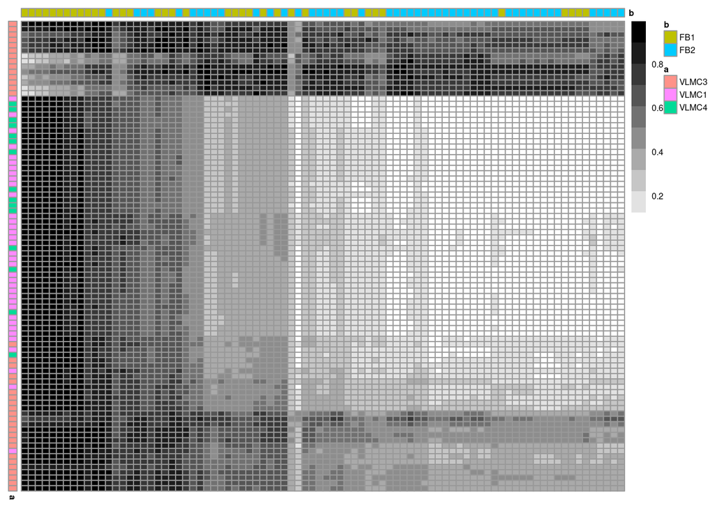

```r
list(
  a = sce_cb,
  b = sce_bth_mb,

  # Select genes for comparison
  g = de_results.group %>% slice_min(pvalue, n = 150) %>% rownames()
) %>%
  with({
    # Keep only the common genes
    g <- intersect(g, intersect(rownames(a), rownames(b)))

    pheatmap::pheatmap(
      cosine(a[g, ], b[g, ]) %>% as.data.frame(),
      show_colnames = FALSE,
      show_rownames = FALSE,
      cluster_cols = TRUE,
      cluster_rows = TRUE,
      treeheight_row = 0,
      treeheight_col = 0,
      fontsize = 6,
      color = grDevices::colorRampPalette(c("white", "black"))(10),
      annotation_row = (
        a@colData %>%
          as.data.frame() %>%
          select(a = celltype)
      ),
      annotation_col = (
        b@colData %>%
          as.data.frame() %>%
          select(b = celltype)
      )
    )
  })
```